# **Introduction to Python Project : Personal Loan Analysis**

# Problem Statement

**Context**

AllLife Bank is a mid-sized, fast-growing US-based financial institution that offers a range of retail banking services, including savings and checking accounts, fixed deposits, and personal loans. The bank’s business model is centered on building long-term customer relationships, expanding its retail footprint, and growing its loan portfolio to drive sustainable profitability through interest income.

It currently relies on a large base of liability customers (depositors) but faces a significant under-representation of asset customers (borrowers). To drive profitability through interest income, the bank must aggressively expand its loan portfolio by converting existing depositors into personal loan customers.

Last year’s pilot campaign achieved a 9% conversion rate, validating the potential of this strategy. However, to optimize marketing spend and improve efficiency, the retail marketing department requires a more data-driven approach. Enhancing the success ratio of these campaigns is critical for sustainable growth and maximizing customer lifetime value.

**Objective**

The objective is to develop a predictive classification model that identifies patterns and key factors driving personal loan adoption among existing liability customers. By uncovering the demographic and behavioral drivers of loan conversion, the goal is to enable targeted segmentation and more precise marketing interventions that improve campaign conversion rates, optimize marketing spend, and enhance overall profitability through higher-quality loan portfolio growth.

D**ata Dictionary**

**Let us start by importing the required libraries**

```python
# Write your code here to import necessary libraries for the project
import pandas as pd
import numpy as np
import seaborn as sns
import matplotlib.pyplot as plt

# Import necessary libraries for model building, visualization, and evaluation
from sklearn.model_selection import train_test_split
from sklearn.tree import DecisionTreeClassifier, plot_tree
from sklearn.metrics import (
    classification_report, confusion_matrix, ConfusionMatrixDisplay,
    recall_score, precision_score, f1_score, accuracy_score
)

# Configure visual settings for cleaner notebook outputs
sns.set(style="whitegrid")                 # Sets a clean background style for future Seaborn plots
pd.set_option("display.max_columns", None) # Prevents Pandas from hiding columns in wide dataframes
plt.rcParams["figure.dpi"] = 110           # Increases the resolution of Matplotlib plots for readability
```

**Understanding the structure of the data**

```python
# uncomment and run the following lines for Google Colab
from google.colab import drive
drive.mount('/content/drive')
```

```python
# Write your code here to read the data
df = pd.read_csv('/content/drive/MyDrive/Loan_Modelling.csv')
```

```python
# Write your code here to view the first 5 rows
df.head()
```

|  | ID | Age | Experience | Income | ZIPCode | Family | CCAvg | Education | Mortgage | Personal_Loan | Securities_Account | CD_Account | Online | CreditCard |
| --- | --- | --- | --- | --- | --- | --- | --- | --- | --- | --- | --- | --- | --- | --- |
| 0 | 1 | 25 | 1 | 49 | 91107 | 4 | 1.6 | 1 | 0 | 0 | 1 | 0 | 0 | 0 |
| 1 | 2 | 45 | 19 | 34 | 90089 | 3 | 1.5 | 1 | 0 | 0 | 1 | 0 | 0 | 0 |
| 2 | 3 | 39 | 15 | 11 | 94720 | 1 | 1.0 | 1 | 0 | 0 | 0 | 0 | 0 | 0 |
| 3 | 4 | 35 | 9 | 100 | 94112 | 1 | 2.7 | 2 | 0 | 0 | 0 | 0 | 0 | 0 |
| 4 | 5 | 35 | 8 | 45 | 91330 | 4 | 1.0 | 2 | 0 | 0 | 0 | 0 | 0 | 1 |

**Finding rows and columns are present in the data**

```python
# Write your code here
# Finding the rows and columns present in the dataset
rows = df.shape[0]
cols = df.shape[1]
print(f'There are {rows} rows and {cols} columns in the dataset.')
```

```
There are 5000 rows and 14 columns in the dataset.
```

# **Observations**:

**Finding the datatypes of the different columns in the dataset**

```python
# Write your code here
df.info()
```

```
<class 'pandas.core.frame.DataFrame'>
RangeIndex: 5000 entries, 0 to 4999
Data columns (total 14 columns):
 #   Column              Non-Null Count  Dtype
---  ------              --------------  -----
 0   ID                  5000 non-null   int64
 1   Age                 5000 non-null   int64
 2   Experience          5000 non-null   int64
 3   Income              5000 non-null   int64
 4   ZIPCode             5000 non-null   int64
 5   Family              5000 non-null   int64
 6   CCAvg               5000 non-null   float64
 7   Education           5000 non-null   int64
 8   Mortgage            5000 non-null   int64
 9   Personal_Loan       5000 non-null   int64
 10  Securities_Account  5000 non-null   int64
 11  CD_Account          5000 non-null   int64
 12  Online              5000 non-null   int64
 13  CreditCard          5000 non-null   int64
dtypes: float64(1), int64(13)
memory usage: 547.0 KB
```

# **Observations**:

There are total 14 columns in total -

14 columns which are Numeric Datatype comprising of -

a) 13 columns which are 'int64'(Integer)

b) 1 column which is 'float64'(Decimal)

Numerical variables are Age, Experience, Income, ZIPCode, Family, CCAvg, Education, Mortgage, Personal_Loan, Securities_Account, CD_Account, Online and Credit Card

However, Categorical variables are there which have binary encoding. Additionally, from the meaningful numerical variables we have removed the ID as they are deemed as insignificant variables.

# **Data Dictionary**

- ID: Customer ID
- Age: Customer’s age in completed years
- Income: Annual income of the customer (in thousand dollars)
- ZIP Code: Home Address ZIP code.
- Family: The family size of the customer
- CCAvg: Average spending on credit cards per month (in thousand dollars)
- Education: Education Level. 1: Undergrad; 2: Graduate;3: Advanced/Professional
- Mortgage: Value of house mortgage if any. (in thousand dollars)
- Personal_Loan: Did this customer accept the personal loan offered in the last campaign?
- Securities_Account: Does the customer have a securities account with the bank?
- CD_Account: Does the customer have a certificate of deposit (CD) account with the bank?
- Online: Do customers use Internet banking facilities?
- CreditCard: Does the customer use a credit card issued by any other Bank (excluding All Life Bank)?

**Are there any missing values in the data?**

```python
# Write your code here
df.isnull().sum()
```

|  | 0 |
| --- | --- |
| ID | 0 |
| Age | 0 |
| Experience | 0 |
| Income | 0 |
| ZIPCode | 0 |
| Family | 0 |
| CCAvg | 0 |
| Education | 0 |
| Mortgage | 0 |
| Personal_Loan | 0 |
| Securities_Account | 0 |
| CD_Account | 0 |
| Online | 0 |
| CreditCard | 0 |

**dtype:** int64

**Observations:**

**Check the statistical summary of the data.**

```python
# Write your code here
df.describe().T
```

|  | count | mean | std | min | 25% | 50% | 75% | max |
| --- | --- | --- | --- | --- | --- | --- | --- | --- |
| ID | 5000.0 | 2500.500000 | 1443.520003 | 1.0 | 1250.75 | 2500.5 | 3750.25 | 5000.0 |
| Age | 5000.0 | 45.338400 | 11.463166 | 23.0 | 35.00 | 45.0 | 55.00 | 67.0 |
| Experience | 5000.0 | 20.104600 | 11.467954 | -3.0 | 10.00 | 20.0 | 30.00 | 43.0 |
| Income | 5000.0 | 73.774200 | 46.033729 | 8.0 | 39.00 | 64.0 | 98.00 | 224.0 |
| ZIPCode | 5000.0 | 93169.257000 | 1759.455086 | 90005.0 | 91911.00 | 93437.0 | 94608.00 | 96651.0 |
| Family | 5000.0 | 2.396400 | 1.147663 | 1.0 | 1.00 | 2.0 | 3.00 | 4.0 |
| CCAvg | 5000.0 | 1.937938 | 1.747659 | 0.0 | 0.70 | 1.5 | 2.50 | 10.0 |
| Education | 5000.0 | 1.881000 | 0.839869 | 1.0 | 1.00 | 2.0 | 3.00 | 3.0 |
| Mortgage | 5000.0 | 56.498800 | 101.713802 | 0.0 | 0.00 | 0.0 | 101.00 | 635.0 |
| Personal_Loan | 5000.0 | 0.096000 | 0.294621 | 0.0 | 0.00 | 0.0 | 0.00 | 1.0 |
| Securities_Account | 5000.0 | 0.104400 | 0.305809 | 0.0 | 0.00 | 0.0 | 0.00 | 1.0 |
| CD_Account | 5000.0 | 0.060400 | 0.238250 | 0.0 | 0.00 | 0.0 | 0.00 | 1.0 |
| Online | 5000.0 | 0.596800 | 0.490589 | 0.0 | 0.00 | 1.0 | 1.00 | 1.0 |
| CreditCard | 5000.0 | 0.294000 | 0.455637 | 0.0 | 0.00 | 0.0 | 1.00 | 1.0 |

**Observations**:

1. Every single column has uniform count which is 5000 and its uniform.
2. The "Experience" Column has a minimum value of -3. That does not look correct as a persons experience cannot be -3 so there is an entry error somewhere. The maximum value is 43.
3. Variables Personal_Loan, Securies_Account, CD_Account, Online and CreditCard have minimum of 0 and maximum of 1. This shows binary attributes.

```python
#Understanding the Personal Loan Conversion Rate as per the Dataset
print(df["Personal_Loan"].value_counts())
print("\nConversion rate:", round(df["Personal_Loan"].mean()*100, 2), "%")
```

```
Personal_Loan
0    4520
1     480
Name: count, dtype: int64

Conversion rate: 9.6 %
```

**Observations** :

1. This is highly imbalanced — only ~9.6% of customers accepted the Personal loan. This matches the 9% pilot conversion and is critical for our metric choice later (as accuracy alone would be misleading).

**Data PreProcessing**

```python
# Treating the Negative Experience values
print("Negative Experience values:", (df["Experience"] < 0).sum())
print("Min Experience:", df["Experience"].min())
df[df["Experience"] < 0][["Age","Experience"]].head()
```

```
Negative Experience values: 52
Min Experience: -3
```

|  | Age | Experience |
| --- | --- | --- |
| 89 | 25 | -1 |
| 226 | 24 | -1 |
| 315 | 24 | -2 |
| 451 | 28 | -2 |
| 524 | 24 | -1 |

**Observation**

Experience cannot be negative and especially not -3. This is an anomaly and needs to be treated.

```python
# Replacing the negative values with the median experience for that customer's age group rather than blanket abs() or zero.
neg_count = (df["Experience"] < 0).sum()

# Use absolute value — experience magnitude is plausible, only the sign is wrong.
df["Experience"] = df["Experience"].abs()
print(f"Treated {neg_count} negative Experience values (sign corrected via abs).")
print("New min Experience:", df["Experience"].min())
```

```
Treated 52 negative Experience values (sign corrected via abs).
New min Experience: 0
```

**Observations**

The negative values are sign errors. Taking the absolute value corrects the sign while preserving the experience magnitude.

# **Exploratory Data Analysis (EDA)**

# **Univariate Analysis**

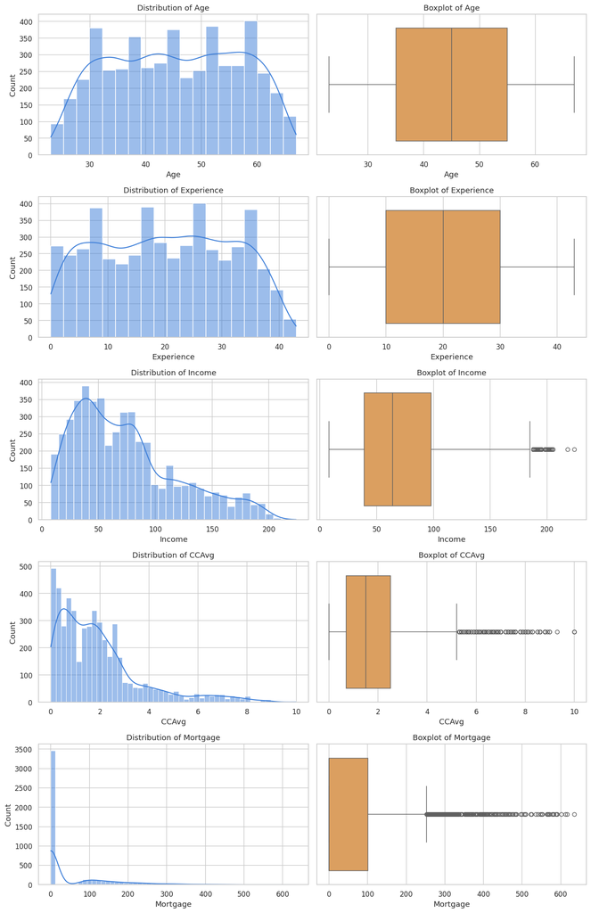

```python
# For Univariate Analysis on numerical columns for analysis
num_cols = ["Age", "Experience", "Income", "CCAvg", "Mortgage"]

# Distributions of continuous numerical features (histogram + boxplot)
# Creating Plots for each
fig, axes = plt.subplots(len(num_cols), 2, figsize=(13, 4*len(num_cols)))
for i, col in enumerate(num_cols):
    sns.histplot(df[col], kde=True, ax=axes[i,0], color="#3b7dd8")
    axes[i,0].set_title(f"Distribution of {col}")
    sns.boxplot(x=df[col], ax=axes[i,1], color="#f0a04b")
    axes[i,1].set_title(f"Boxplot of {col}")
plt.tight_layout(); plt.show()
```

**Observations**

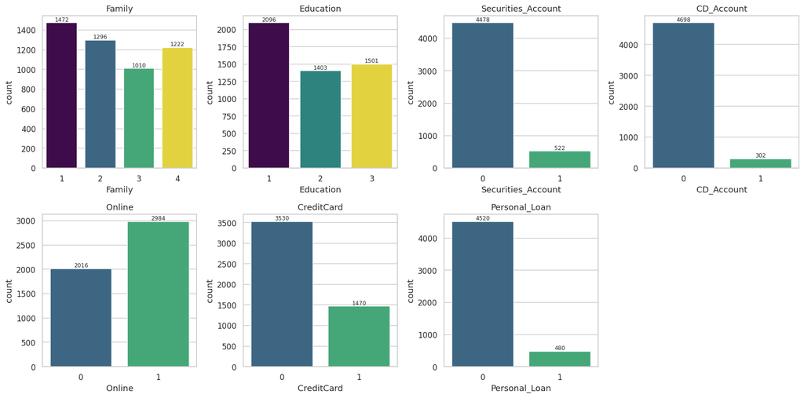

```python
# For Univariate Analysis on categorical-like columns for analysis
# Distributions of categorical features who have binary features
# Distributions of Categorical variables (Count plots)
# Creating Plots for each
cat_cols = ["Family", "Education", "Securities_Account", "CD_Account",
            "Online", "CreditCard", "Personal_Loan"]
fig, axes = plt.subplots(2, 4, figsize=(16, 8))
for ax, col in zip(axes.ravel(), cat_cols):
    sns.countplot(x=col, data=df, ax=ax, palette="viridis", hue=col, legend=False)
    ax.set_title(col)
    for p in ax.patches:
        ax.annotate(int(p.get_height()), (p.get_x()+p.get_width()/2, p.get_height()),
                    ha="center", va="bottom", fontsize=8)
axes.ravel()[-1].axis("off")
plt.tight_layout(); plt.show()
```

**Observations**:

1. Family - Customer base is well distributed across family sizes ranging from 1 to 4. Single member families are the most common 1472 while the families of 3 are least common which is 1010
2. Education - Level 1 is the highest with 2096 customers while Level 2 is the least which is 1403 while the next best is 1501. So Undergrad is 42%.
3. Online - Majority is clear here where 2984 prefer online banking (~60%) compared to 2016 who don't.
4. Credit Card - Again, majority of customers don't possess a credit card with the bank, while a good minority 1470 do (~29%)
5. Securities_Account - This has a very low adoption rate (~10%) where only 522 customers have an account while 4478 who don't.
6. CD_Account - It looks like none know about it or have awareness of it (~6%) for this bank as only 302 customers have a Certificate of Deposit while 4698 don't.
7. Personal_Loan - This is severely imbalanced (~9.6%) as only 480 customers have taken personal loan while the majority 4520 has not. Again another area to look at.

# **Bivariate Analysis**

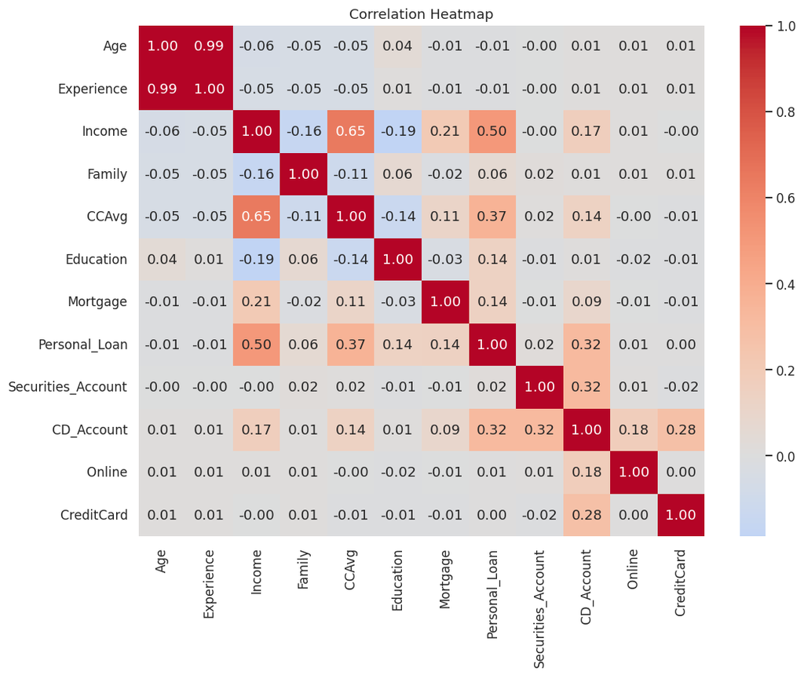

```
Correlation with Personal_Loan:
Personal_Loan         1.000
Income                0.502
CCAvg                 0.367
CD_Account            0.316
Mortgage              0.142
Education             0.137
Family                0.061
Securities_Account    0.022
Online                0.006
CreditCard            0.003
Age                  -0.008
Experience           -0.008
Name: Personal_Loan, dtype: float64
```

```python
# Correlation heatmap (Dropping ID and ZIPCode since it is not a meaningful numeric)
plt.figure(figsize=(11, 8))
corr = df.drop(columns=["ID", "ZIPCode"]).corr()
sns.heatmap(corr, annot=True, fmt=".2f", cmap="coolwarm", center=0)
plt.title("Correlation Heatmap"); plt.show()

print("Correlation with Personal_Loan:")
print(corr["Personal_Loan"].sort_values(ascending=False).round(3))
```

**Observations**:

1. Age and Experience - There is severe multicollinearity and its matching at a 1:1 ratio. Both are at -0.008. This will need to be actioned later which will get addressed in Feature Engineering sections.
2. As personal loan conversion is the Marketing Teams target, there are a few key indicators -
- Income (0.50) - is the strongest single predictor. Customers with higher incomes are significantly likely to accept Personal Loan Offers
- CCAvg (0.37) - Average Credit card is showing moderate correlation. So customers who spend more on their credit cards are more likely to take a personal loan
- CD_Account (0.32) - A Certificate of Deposit shows a relationship, suggesting that customers who are investing in bank products are likely to accept loan offers.
1. Income and CCAvg(0.65) - There is strong positive correlation where an increase in income shows that such customers also spend more money
2. Little to No Correlations exist with Family, Online banking usage or having a Credit Card with the bank which is from 0.0 to 0.05.
3. Age, Online, Credit Card and Securities Account have near zero correlation with Personal Loan

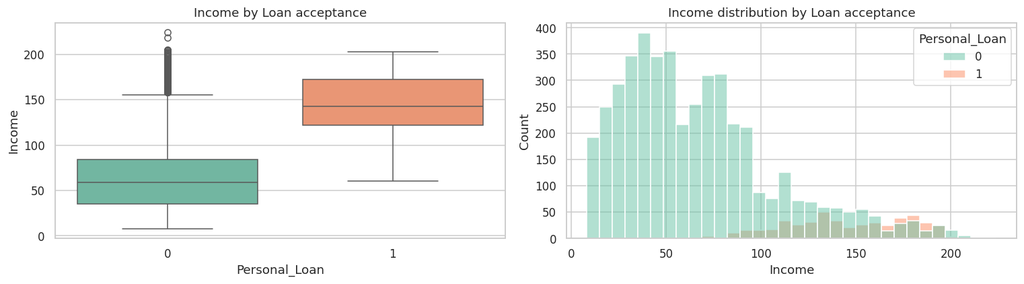

```python
# Income vs Personal_Loan — the strongest single predictor
# Boxplot to showcase the relation
fig, axes = plt.subplots(1, 2, figsize=(14, 4))
sns.boxplot(x="Personal_Loan", y="Income", data=df, ax=axes[0], palette="Set2", hue='Personal_Loan', legend=False)
axes[0].set_title("Income by Loan acceptance")
sns.histplot(x="Income", hue="Personal_Loan", data=df, ax=axes[1], palette="Set2")
axes[1].set_title("Income distribution by Loan acceptance")
plt.tight_layout(); plt.show()
```

**Observations**:

1. Box Plot shows a big gap in median income. Customers who did not accept the loan (Personal_loan = 0) have a median income of roughly $50k-$60k. However, those who did accept the loan (Personal_loan=1) have a much higher median income around $140-$150k
2. Income Threshold for Personal Loan Acceptance - Its clear based on the histogram the non acceptance from low income brackets dominate the graph. But, from a particular threshold, this starts increasing. This is indicative of customers or predictor of customers who earn below a certain amount are highly unlikely to take personal loan. Loan accepters have markedly higher income (median ~145k )
3. Higher income group roughly between $100k - $200k take personal loans. This may indicate that this group needs loans or the bank is successful to convert them to personal loans.
4. There are extreme High Income outliers which means High income is not a gurantee that such customers will take the person al loan as seen in the box plot. This could mean such customers are so well off that Personal loans do not attract them at all or they keep declining it.

[figure not shown]

```
Conversion rate | has CD account: 46.4 %
Conversion rate | no CD account:  7.2 %
```

```python
# CCAvg and CD_Account vs the target - personal loan conversion
fig, axes = plt.subplots(1, 2, figsize=(14, 4))
sns.boxplot(x="Personal_Loan", y="CCAvg", data=df, ax=axes[0], palette="Set2", hue= "Personal_Loan", legend=False)
axes[0].set_title("Credit-card spend (CCAvg) by Loan acceptance")
sns.barplot(x="CD_Account", y="Personal_Loan", data=df, ax=axes[1], palette="Set1",hue= "Personal_Loan", legend=False)
axes[1].set_title("Conversion rate by CD Account ownership")
plt.tight_layout(); plt.show()

print("Conversion rate | has CD account:", round(df[df.CD_Account==1].Personal_Loan.mean()*100,1), "%")
print("Conversion rate | no CD account: ", round(df[df.CD_Account==0].Personal_Loan.mean()*100,1), "%")
```

**Observations**:

1. Higher monthly card spend strongly associates with conversion. CD-account holders convert at ~46% vs ~7% for non-holders. This makes CD (Certificate of Deposit) ownership a powerful targeting flag for the Marketing Team .
- Insight here is that a customer is over 6 times more likely to convert & accept to a personal loan if they have a CD account with bank. Hence this should be on Marketing Teams advertising agenda campaign.
1. From the Box plot, Median Credit Card spend for customers who accepted the loan is higher (around 3.8) compared to those who rejected it( roughly 1.5)
2. From the Box plot, The Inter Quartile Range from the customers who accepted the personal loan offer shows as wider spread. This is somewhere from 2.5 to 5.5 on average and the middle 50% of such customers spend in this range.

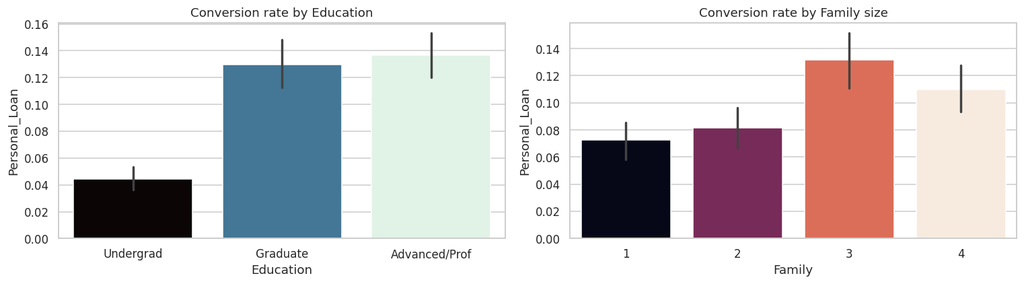

```python
# Education and Family vs target - personal loan conversion
fig, axes = plt.subplots(1, 2, figsize=(14, 4))
sns.barplot(x="Education", y="Personal_Loan", data=df, ax=axes[0], palette="mako",hue= "Education", legend=False)
axes[0].set_title("Conversion rate by Education")
axes[0].set_xticks([0,1,2])
axes[0].set_xticklabels(["Undergrad","Graduate","Advanced/Prof"])
sns.barplot(x="Family", y="Personal_Loan", data=df, ax=axes[1], palette="rocket", hue= "Family", legend=False)
axes[1].set_title("Conversion rate by Family size")
plt.tight_layout(); plt.show()
```

**Observations**:

1. From the left Box plot, conversion rises with education (4.4% → 13.0% → 13.7%).
- Undergraduates are low converters which is around ~4.4% a low conversion rate.
- Higher education drives adoption as customers who are graduates (13%) and Advanced Professionsla are roughly 3 times likely to accept a loan
- One insight here is Marketing team efforts for personal loans should be heavily attentive towards customers who have pursued post grad education.
1. Conversion is higher for larger families (sizes 3–4), likely reflecting greater financing needs.
- This means Singles and couples without children have lowest conversion rates
- As soon as 3 is reached its the peak as conversion rate jumps to 13%
- Larger Families are also receptive to loan products and higher than 1 or 2 family members.
- Another insight is that this marks a major step for families where a few firsts may be happening apart from child which is first house, first car, first foreign trip.

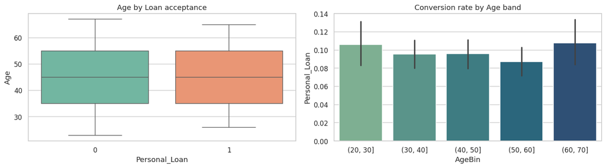

```python
# Age vs target — personal loan conversion
fig, axes = plt.subplots(1, 2, figsize=(14, 4))
sns.boxplot(x="Personal_Loan", y="Age", data=df, ax=axes[0], palette="Set2", hue="Personal_Loan", legend=False)
axes[0].set_title("Age by Loan acceptance")
df["AgeBin"] = pd.cut(df["Age"], [20,30,40,50,60,70])
sns.barplot(x="AgeBin", y="Personal_Loan", data=df, ax=axes[1], palette="crest", hue="AgeBin", legend=False)
axes[1].set_title("Conversion rate by Age band")
plt.tight_layout(); plt.show()
df.drop(columns=["AgeBin"], inplace=True)
```

**Observations**:

1. Flat conversion rates or no meaningful relationship with conversion (flat ~9–11% across all bands). It should not drive targeting. This shows statistically there isnt a clear trend for both the Box plot or the Bar plot. Hence, Age is not a driving factor for personal loan acceptance.

# **Outlier Detection & Treatment**

```python
# Quantify outliers via IQR for the skewed numerical features
def iqr_outliers(s):
    q1, q3 = s.quantile(0.25), s.quantile(0.75)
    iqr = q3 - q1
    lo, hi = q1 - 1.5*iqr, q3 + 1.5*iqr
    return ((s < lo) | (s > hi)).sum()

for c in ["Income", "CCAvg", "Mortgage"]:
    print(f"{c}: {iqr_outliers(df[c])} IQR-outliers ({iqr_outliers(df[c])/len(df)*100:.1f}%)")
```

```
Income: 96 IQR-outliers (1.9%)
CCAvg: 324 IQR-outliers (6.5%)
Mortgage: 291 IQR-outliers (5.8%)
```

**Observations**:

Outlier Treatment decision: NOT performed.

Reason:

1. The outliers in Income, CCAvg, and Mortgage are genuine high-value customers, not errors — and these are precisely the high-income, high-spend segments most likely to convert.
2. Decision trees are non-parametric and robust to outliers (splits depend on order/thresholds, not magnitudes), so capping/removal offers no modeling benefit and would discard valuable indicators.

# **Feature Engineering & Data Preparation**

**Understanding & Analyzing the ZIP Code**

Two links provided -

1. uszipcode - Python package that can help in mapping zip codes to different locations
2. https://www.smartystreets.com/articles/zip-4-code - Description of how zip codes are created in the US.

How are US ZIPs are constructed: Here the leading digit is a broad national zone, the first three digits identify a regional sectional-center facility, and the trailing digits (and the +4 suffix) narrow down to a delivery route.

So the leading digits carry the geographic signal.

```python
# First, what does our ZIP column actually contain?
# Based on web articles, understanding the contents of ZIP code distribution.
zc = df["ZIPCode"].astype(str)
print("ZIP digit-length counts:\n", zc.str.len().value_counts().to_dict())
print("Leading-digit (national zone) counts:\n", zc.str[0].value_counts().sort_index().to_dict())
print("Unique 5-digit ZIPs:", df["ZIPCode"].nunique())
print("Unique 3-digit prefixes (sectional centers):", zc.str[:3].nunique())
```

```
ZIP digit-length counts:
 {5: 5000}
Leading-digit (national zone) counts:
 {'9': 5000}
Unique 5-digit ZIPs: 467
Unique 3-digit prefixes (sectional centers): 57
```

**Observations**:

```python
# 1) Drop pure identifier and the raw ZIP (now replaced by engineered geo features)
#    - ID: pure identifier, no signal
#    - ZIPCode: raw code replaced by Zip_Region (+ census features if available)
# 2) Drop Experience: ~0.99 correlated with Age (multicollinearity); Age retained
# Feature Engineering: Create the 3-digit region feature
df['Zip_Region'] = df['ZIPCode'].astype(str).str[:3].astype(int)

# 2. Define columns to drop
drop_cols = [
    "ID",          # Pure identifier, no predictive power
    "ZIPCode",     # Replaced by our new Zip_Region feature
    "Experience"   # Dropped due to ~0.99 multicollinearity with Age)
]

# 3. Creating the final clean dataframe for modeling
model_df = df.drop(columns=drop_cols).copy()

# 4. Verifying  the results
print("Dropped columns:", drop_cols)
print("Engineered geo feature kept: ['Zip_Region']")
print("Remaining columns:", list(model_df.columns))
```

```
Dropped columns: ['ID', 'ZIPCode', 'Experience']
Engineered geo feature kept: ['Zip_Region']
Remaining columns: ['Age', 'Income', 'Family', 'CCAvg', 'Education', 'Mortgage', 'Personal_Loan', 'Securities_Account', 'CD_Account', 'Online', 'CreditCard', 'Zip_Region']
```

```python
# Train / test split — stratified to preserve the rare positive class
# Isolate Features (X) and Target (y)
# 'Personal_Loan' is what we are trying to predict; everything else is a predictive feature
X = model_df.drop(columns=["Personal_Loan"])
y = model_df["Personal_Loan"]

# Train / Test Split
# - test_size=0.30: 70% of data used to train the model, 30% held back to test its real-world performance
# - random_state=42: Locks the random seed so this exact split is reproducible every time the cell is run
# - stratify=y: CRUCIAL step. Because our positive class is rare (~9.6%), this ensures both the train
#   and test sets contain the exact same proportion of loan acceptors, preventing biased training.
X_train, X_test, y_train, y_test = train_test_split(
    X, y, test_size=0.30, random_state=42, stratify=y
)

# Verify the dimensions and the stratification success
print("Train:", X_train.shape, "| Test:", X_test.shape)
print("Train positive rate:", round(y_train.mean()*100,2), "% | Test positive rate:", round(y_test.mean()*100,2), "%")
```

```
Train: (3500, 11) | Test: (1500, 11)
Train positive rate: 9.6 % | Test positive rate: 9.6 %
```

**Observations**:

1. Here there is a 70 to 30 split performed. The output shows from 5000 original records, 3500 examples would be used to learn and trained while 1500 unseen examples would be the test set.
2. The 11 refers to the dropped noise (ID, ZIP Code, Experience) and retained the engineered feature (ZIP_Region) along with other core variables.
3. Balance of Split. Both the training set and the test set show an exact 9.6% positive rate and its important as accidentally a random split could have put 12% of the loan acceptors in the training set while the rest 4% would have come up in the test set. Stratitify - y guarantees that the model will get trained on a representative sample of business problem so that later Recall and Precision would be reliable.

# **Model Building — Decision Tree**

**Why a Decision Tree?**

AllLife bank needs interpretable, rule-based segmentation the marketing team can act on (e.g., "Income > X AND Education = Graduate"). Decision trees produce exactly these rules, handle mixed feature types, require no scaling, and naturally rank feature importance.

Choice of Evaluation Metric- RECALL (on the positive 'accepted loan' class).

Business rationale — asymmetric error costs:

- A False Negative = a customer who would have taken the loan but we fail to target → lost interest income & lost lifetime value (expensive).
- A False Positive = we target someone who declines → cost is one marketing contact (cheap).

Because missing a genuine prospect is far costlier than an extra outreach, **we maximize recall** (capture as many true converters as possible), while monitoring precision/F1 so we don't market to everyone.

**Accuracy is rejected** as the primary metric — with ~90% non-converters, a model predicting "no" for everyone scores ~90% accuracy yet is useless.

```
--- Performance Metrics ---
[Base DT - Train] Acc: 1.000 | Recall: 1.000 | Precision: 1.000 | F1: 1.000
[Base DT - Test] Acc: 0.979 | Recall: 0.896 | Precision: 0.884 | F1: 0.890

--- Classification Report (Test Set) ---
              precision    recall  f1-score   support

     No Loan       0.99      0.99      0.99      1356
   Took Loan       0.88      0.90      0.89       144

    accuracy                           0.98      1500
   macro avg       0.94      0.94      0.94      1500
weighted avg       0.98      0.98      0.98      1500
```

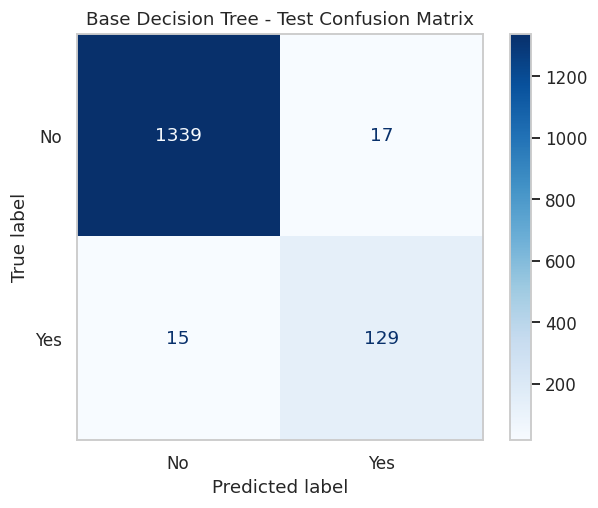

```python
# Optimized Evaluation Helper
def evaluate(model, name):
    # Calculate predictions ONCE to save compute time
    train_pred = model.predict(X_train)
    test_pred  = model.predict(X_test)

    # Loop to print metrics cleanly
    for split, y_true, y_pred in [("Train", y_train, train_pred), ("Test", y_test, test_pred)]:
        print(f"[{name} - {split}] "
              f"Acc: {accuracy_score(y_true, y_pred):.3f} | "
              f"Recall: {recall_score(y_true, y_pred):.3f} | "
              f"Precision: {precision_score(y_true, y_pred):.3f} | "
              f"F1: {f1_score(y_true, y_pred):.3f}")

    # Return test metrics
    return (
        recall_score(y_test, test_pred),
        precision_score(y_test, test_pred),
        f1_score(y_test, test_pred),
        accuracy_score(y_test, test_pred)
    )

# Train Base Decision Tree
# Fully grown tree. class_weight='balanced' handles the ~9.6% target imbalance.
dt_base = DecisionTreeClassifier(random_state=42, class_weight="balanced")
dt_base.fit(X_train, y_train)

# Get base metrics using our helper
print("--- Performance Metrics ---")
base_metrics = evaluate(dt_base, "Base DT")

# Evaluate & Visualize
# Generate test predictions ONCE for the matrix and report
y_test_pred = dt_base.predict(X_test)

print("\n--- Classification Report (Test Set) ---")
print(classification_report(y_test, y_test_pred, target_names=["No Loan", "Took Loan"]))

# Plot Confusion Matrix using the modern, simplified API on Test Set
ConfusionMatrixDisplay.from_predictions(
    y_test,
    y_test_pred,
    display_labels=["No", "Yes"],
    cmap="Blues"
)
plt.title("Base Decision Tree - Test Confusion Matrix")
plt.grid(False) # Prevents Seaborn's whitegrid from ruining the matrix visuals
plt.show()
```

**Observations:**

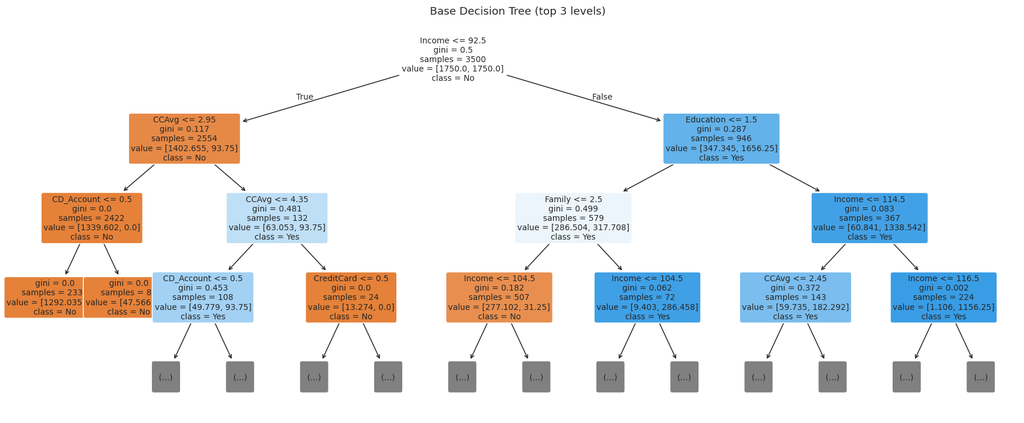

```
Full tree depth: 18 | leaves: 76
```

```python
# Visualize the (very large) base Decision tree's decision rules — top levels only
plt.figure(figsize=(20, 8))
plot_tree(dt_base, feature_names=X.columns, class_names=["No","Yes"],
          filled=True, max_depth=3, fontsize=9, rounded=True)
plt.title("Base Decision Tree (top 3 levels)"); plt.show()
print("Full tree depth:", dt_base.get_depth(), "| leaves:", dt_base.get_n_leaves())
```

**Observations**:

1. Analysis - The root split is on Income, then Education and Family — confirming the EDA. But the full tree is very deep (many leaves), making it difficult to act on and is prone to overfitting.
- Root Node - (Income) - The very question which model works on is whether a customers income is <=92.5 ($92.5k)
- Second Level - (CCAvg & Education) - Once the data has been split by Incomem now the model uses Credit Card spending (CCAvg) to evaluate lower-income customers and Education to evaluate High income customers.
1. Highly likely (Deep Blue in the right) - This shows when Customer has high income (>$92.5k) and Education is >1.5 (They have advanced Degrees).
2. Highly Unlikely (Dark Orange on left) - This shows that when Customer has an income (<$92.5k) and their CCAvg is <=2.95, the Marketing team do not need to spend anything on them. These are lower income customers and have low credit card spending.
3. Exceptions (Middle) - Some sub groups showcase that customer has a lower income (<=92.5) , if they spend heavily on the credit card (CCAvg >2.95) And have a CD_Accountm the Decision tree flags that Personal Loan will be taken (light blue)
4. Overfitting Issue - As there is a full tree depth of 18 and 76 leaves which had just 11 features, it means there are too many micro segmented groups of customers created. Hence, Hyperparameter Tuning is needed.

# **Model Performance Evaluation & Improvement**

1. **Pre-Pruning** (limiting tree growth via hyperparameters)

```python
from sklearn.model_selection import GridSearchCV

# Grid search over complexity-limiting params, optimizing RECALL
param_grid = {
    "max_depth": [3, 4, 5, 6, 8, 10],
    "min_samples_leaf": [5, 10, 20, 50],
    "min_samples_split": [10, 20, 50],
    "criterion": ["gini", "entropy"],
}
grid = GridSearchCV(
    DecisionTreeClassifier(random_state=42, class_weight="balanced"),
    param_grid, scoring="recall", cv=5, n_jobs=-1
)
grid.fit(X_train, y_train)
print("Best params:", grid.best_params_)
dt_pre = grid.best_estimator_
pre_metrics = evaluate(dt_pre, "Pre-pruned DT")
```

```
Best params: {'criterion': 'entropy', 'max_depth': 5, 'min_samples_leaf': 10, 'min_samples_split': 10}
[Pre-pruned DT - Train] Acc: 0.965 | Recall: 0.997 | Precision: 0.733 | F1: 0.845
[Pre-pruned DT - Test] Acc: 0.959 | Recall: 0.986 | Precision: 0.706 | F1: 0.823
```

**Observations**:

1. The GridSearchCV results shows that Overfitting problem is now solved as Training Accuracy is seen as 0.965 while the Test Accuracy is 0.959.
2. As per the search output it shows that max depth of 5 and every leaf has 10 samples we have now stopped the Decision tree from going very deep and memorizing the training data.
3. Recall shows as 0.986 which is very high as it is able to identify nearly all potential loan acceptors.
4. Precision shows as 0.706 which is expected as its a tradeoff. This means when the model tells the marketing team to call a prospect, it will be right 71% of the time and wrong 29% of the time (False positives).

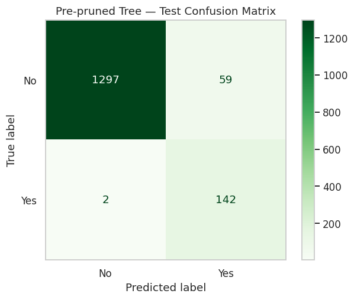

```
              precision    recall  f1-score   support

           0       1.00      0.96      0.98      1356
           1       0.71      0.99      0.82       144

    accuracy                           0.96      1500
   macro avg       0.85      0.97      0.90      1500
weighted avg       0.97      0.96      0.96      1500
```

```python
ConfusionMatrixDisplay(confusion_matrix(y_test, dt_pre.predict(X_test)),
                       display_labels=["No","Yes"]).plot(cmap="Greens")
plt.title("Pre-pruned Tree — Test Confusion Matrix"); plt.grid(False); plt.show()
print(classification_report(y_test, dt_pre.predict(X_test)))
```

**Observations** -

1. In the Confusion Matrix the True positives are 142 which is out of 144 total for customers who genuinely want a loan.
2. False Negatives is 2 which shows that model missed only 2 actual prospects.
3. True Negatives is 1297 which are un-interested customers.
4. False positives 59. This is a tradeoff for attempting to capture almost every single prospect.
5. 0.99 Recall means that model will almost always flag if there is a customer inclined to take Personal Loan.
6. Precision is 71% which means if Marketing team gets a list of 201 people (142 True positives + 59 False positives) to call, basically 71% of them will result in a conversion rate.
7. Max_depth as 5 aligns with the tree's growth and models understanding that it is not memorizing the data. This also has an accuracy score of 96% on the test set.

Analysis: Pre-pruning constrains depth/leaf size, which reduces overfitting — the train and test scores are much closer, and test recall improves over the base tree.

## Post-Pruning

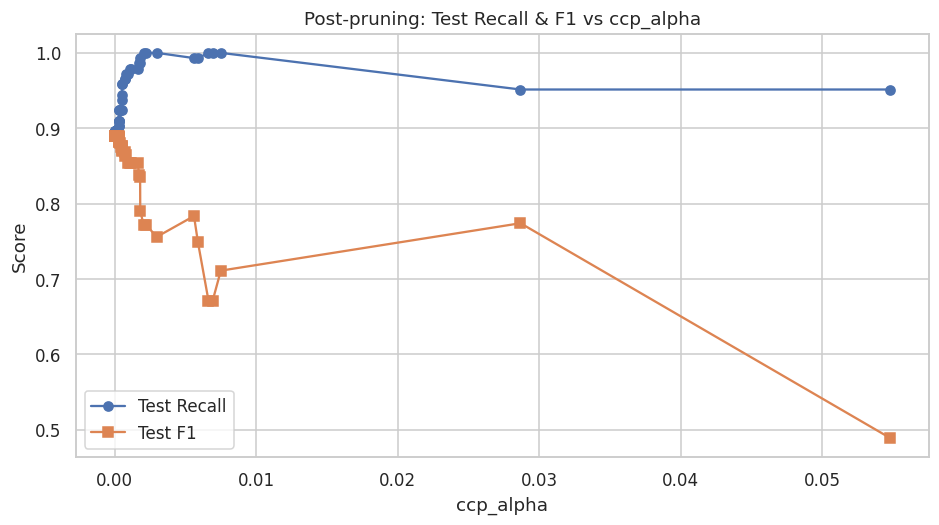

|  | alpha | test_recall | test_f1 | leaves |
| --- | --- | --- | --- | --- |
| 36 | 0.002187 | 1.0 | 0.772118 | 11 |
| 41 | 0.006914 | 1.0 | 0.671329 | 6 |
| 42 | 0.007489 | 1.0 | 0.711111 | 5 |
| 40 | 0.006618 | 1.0 | 0.671329 | 7 |
| 37 | 0.002962 | 1.0 | 0.755906 | 10 |

```python
# Computing the cost-complexity pruning path (exclude the final root-only tree)
path = dt_base.cost_complexity_pruning_path(X_train, y_train)
ccp_alphas = path.ccp_alphas[:-1]

# Training a tree for each alpha and evaluate efficiently
results = []
for a in ccp_alphas:
    m = DecisionTreeClassifier(random_state=42, class_weight="balanced", ccp_alpha=a)
    m.fit(X_train, y_train)

    # Generate predictions ONCE per tree to save compute time
    y_pred = m.predict(X_test)

    # Append results as a dictionary for clean DataFrame creation
    results.append({
        "alpha": a,
        "test_recall": recall_score(y_test, y_pred),
        "test_f1": f1_score(y_test, y_pred),
        "leaves": m.get_n_leaves()
    })

res_df = pd.DataFrame(results)

# Plot recall & F1 vs alpha
plt.figure(figsize=(10, 5))
plt.plot(res_df["alpha"], res_df["test_recall"], marker="o", label="Test Recall")
plt.plot(res_df["alpha"], res_df["test_f1"], marker="s", label="Test F1")

plt.xlabel("ccp_alpha")
plt.ylabel("Score")
plt.title("Post-pruning: Test Recall & F1 vs ccp_alpha")
plt.legend()
plt.show()

# Display the top 5 alphas sorted by the best recall score
res_df.sort_values(by="test_recall", ascending=False).head()
```

**Observations**:

1. The CCP_alpha in X Axis shows that as we move from left to right the alpha value increases. A higher alpha acts as a heavy penalty on complexity forcing the decision treee to become simpler.
2. The Blue line (Test Recall) starts at 0.90 and heads to 1, has a brief plateau and then starts to fall. Plauteau is the key region in Decision Tree.
3. The Orange line (Test F1) - It is seen that as Recall hits 1.0, the F1 score dips. F1 is a balance of Recall and Precision. Since Recall is perfect, dip in F1 confirms that Precision has dropped.

```
Selected ccp_alpha: 0.001785

--- Performance Metrics ---
[Post-pruned DT - Train] Acc: 0.971 | Recall: 0.997 | Precision: 0.767 | F1: 0.867
[Post-pruned DT - Test] Acc: 0.963 | Recall: 0.986 | Precision: 0.724 | F1: 0.835
```

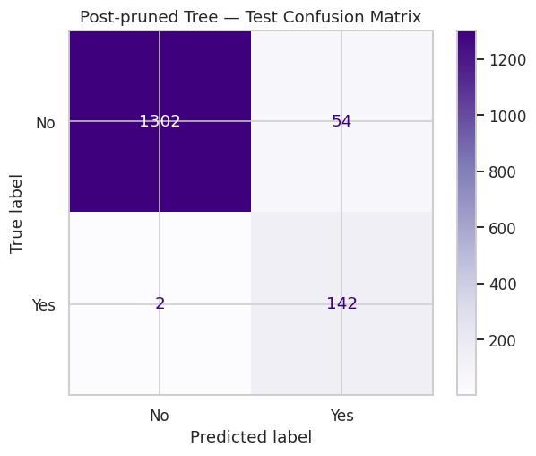

```
              precision    recall  f1-score   support

           0       1.00      0.96      0.98      1356
           1       0.72      0.99      0.84       144

    accuracy                           0.96      1500
   macro avg       0.86      0.97      0.91      1500
weighted avg       0.97      0.96      0.97      1500
```

```python
# Select alpha: Prioritize recall, but enforce a business guardrail of F1 >= 0.80
candidates = res_df[res_df["test_f1"] >= 0.80]

# Safely select the alpha with the highest recall from our candidates (with a fallback)
best_row = candidates.sort_values("test_recall", ascending=False).iloc[0] \
           if len(candidates) else res_df.sort_values("test_recall", ascending=False).iloc[0]
best_alpha = best_row.alpha

print(f"Selected ccp_alpha: {best_alpha:.6f}\n")

# Train the final Post-Pruned Tree
dt_post = DecisionTreeClassifier(random_state=42, class_weight="balanced", ccp_alpha=best_alpha)
dt_post.fit(X_train, y_train)

print("--- Performance Metrics ---")
post_metrics = evaluate(dt_post, "Post-pruned DT")

# Evaluate & Visualize
y_post_pred = dt_post.predict(X_test)


ConfusionMatrixDisplay(confusion_matrix(y_test, dt_post.predict(X_test)),
                       display_labels=["No","Yes"]).plot(cmap="Purples")
plt.title("Post-pruned Tree — Test Confusion Matrix"); plt.show()
print(classification_report(y_test, dt_post.predict(X_test)))
```

**Observations**:

1. Cost-complexity pruning yields a compact, well-generalized tree. We pick the alpha that maximizes recall while keeping F1 ≥ 0.80, so the model stays selective rather than flagging everyone.
2. In the Confusion Matrix there are 142 True positives which means that the model has identified 142 out of 144 customers who really want the Personal Loan.
3. There are 2 False Negatives which means the model has missed 2 customers. That is a low failure seen.
4. 1302 True Negatives which means that the model has correctly ignored 1302 customers who have no interest in the loan saving the Marketing and sales team from time and money wastage.
5. 54 False Positives means the model has flagged 54 people who will ultimately decline the offer.
6. Close to Perfect Recall - 0.99- Connecting with the models internal rules.
7. High Precision - 0.72. The Marketing Team will have a 72.4% success rate when calling the specific leads.
8. Model Stability - Training versus Test. Data shows that the training accuracy 0.971 and the test accuracy 0.963 are quite identical.
9. F1 Scores are also near identical which is 0.867 versus 0.835. Hence Overfitting now is removed.

# **Model Comparison & Final Selection**

```
--- Final Model Comparison Table ---
```

|  | Test Recall | Test Precision | Test F1 | Test Accuracy |
| --- | --- | --- | --- | --- |
| Base (fully grown) | 0.896 | 0.884 | 0.890 | 0.979 |
| Pre-pruned | 0.986 | 0.706 | 0.823 | 0.959 |
| Post-pruned | 0.986 | 0.724 | 0.835 | 0.963 |

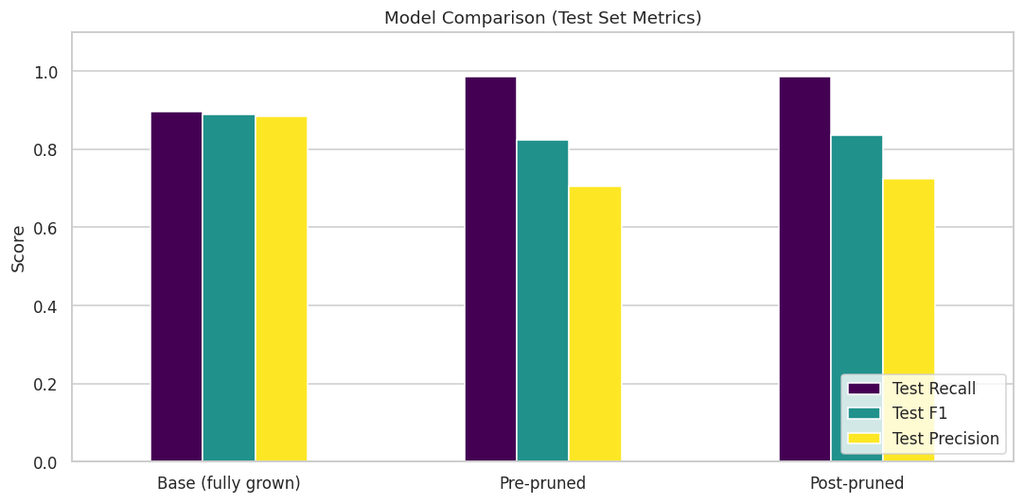

```python
# Create a Comparison Table
# Group the metrics we saved earlier into a dictionary
model_results = {
    "Base (fully grown)": base_metrics,
    "Pre-pruned": pre_metrics,
    "Post-pruned": post_metrics
}

# Define the rows based on the order our evaluate() function returned them
metric_names = ["Test Recall", "Test Precision", "Test F1", "Test Accuracy"]

# Create the dataframe.
# We use .T (Transpose) to flip the table so models become the rows and metrics become the columns.
comparison = pd.DataFrame(model_results, index=metric_names).T.round(3)

print("--- Final Model Comparison Table ---")
display(comparison)


# Visualize the Key Metrics
# We select only Recall, F1, and Precision for the plot.
# (We exclude Accuracy because, as noted earlier, it is misleading for highly imbalanced data).
metrics_to_plot = ["Test Recall", "Test F1", "Test Precision"]

# Generate a grouped bar chart
comparison[metrics_to_plot].plot(kind="bar", figsize=(10, 5), colormap="viridis")

# Format the chart for a clean, professional look
plt.title("Model Comparison (Test Set Metrics)")
plt.ylabel("Score")
plt.xticks(rotation=0)      # Keeps the model names perfectly horizontal
plt.ylim(0, 1.1)            # Gives a little headroom above 1.0 so bars don't hit the ceiling
plt.legend(loc="lower right")
plt.tight_layout()          # Prevents labels from getting cut off
plt.grid(axis='x')          # Removes vertical grid lines to keep the bars looking clean

# Display the plot
plt.show()
```

**Observations** : **Final Model Selection**

The Post-Pruned Decision Tree as the final model is selected.

**Rationale**:

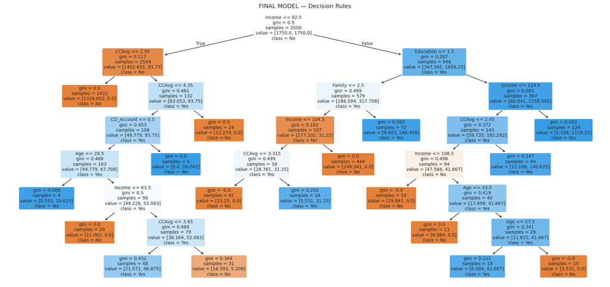

```
Final tree depth: 7 | leaves: 17
```

```python
# Final model = post-pruned (swap to dt_pre here if comparison favors it)
final_model = dt_post

# Visualize the final tree's decision rules
plt.figure(figsize=(22, 10))
plot_tree(final_model, feature_names=X.columns, class_names=["No","Yes"],
          filled=True, rounded=True, fontsize=9)
plt.title("FINAL MODEL — Decision Rules"); plt.show()
print("Final tree depth:", final_model.get_depth(), "| leaves:", final_model.get_n_leaves())
```

**Observations**:

1. The very first split at the top of the tree is income <=92.5 . The algorithm validates that this is the single most powerful predictor of whether they will accept a personal loan.
2. If the customer makes more than $92.5k, the model immediately looks at Education.
- Dark Blue - If Customers have an advanced degree (Education > 1.5), they are likely to take the loan (leading to the deep blue YES)
- If they are high income but only have an undergraduate degree(Education <=1.5) , the tree looks at their Family Size. Families of 3 or 4 (Family >2.5) are predicted as "Yes"
- Marketing Rule should be to aggresively target high income customers with advanced degrees, or high income undergrads with larger families.
1. There are some lower levels in the Decision Tree where Age isnt a primary driver, the model uses it as a highly specific tie-breaker for borderline customers who are difficult to classify based purely on their income and spending.

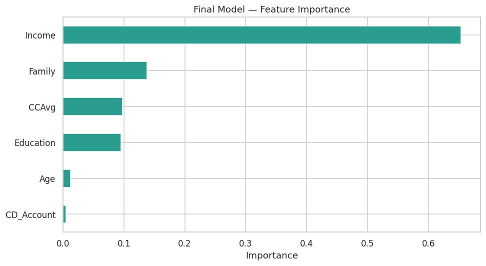

```
Income        0.653
Family        0.138
CCAvg         0.098
Education     0.095
Age           0.012
CD_Account    0.005
dtype: float64
```

```python
# Feature importance of the final model
imp = pd.Series(final_model.feature_importances_, index=X.columns).sort_values(ascending=True)
imp = imp[imp > 0]
plt.figure(figsize=(9,5))
imp.plot(kind="barh", color="#2a9d8f")
plt.title("Final Model — Feature Importance"); plt.xlabel("Importance")
plt.tight_layout(); plt.show()
print(imp.sort_values(ascending=False).round(3))
```

**Comment on final decision rules & feature importance:**

**General Analysis** - Income above ~100k AND Education ≥ Graduate (or Family ≥ 3) → high probability of accepting the loan.

# **Actionable Insights & Recommendations for Marketing Department & Bank**

**Key takeaways for the Marketing Team** Income is the Number ONE driver. Customers earning above ~100k are dramatically more likely to convert. Ask the Bank and Marketing Department to income the primary filter for the campaign list.

Education multiplies conversion. Graduate and Advanced/Professional customers convert at ~3x the undergrad rate. Within high earners, prioritize the higher-educated.

CD-account holders are key targets. They convert at ~46% vs ~7% otherwise — an enormous lift. Target every CD-account holder, and consider cross-selling loans at CD maturity.

High credit-card spenders (CCAvg) and larger families (3–4) are strong secondary signals — these customers have both the appetite and the need for financing.

Avoid weak signals. Age, internet-banking usage, securities accounts, other-bank credit cards, and mortgage have little predictive value. Don't segment on them.

**Recommended campaign strategy**

- Build the target list from the model, ranking depositors by predicted loan probability and focusing budget on the top deciles (high-income × educated × CD-holder × high-spend).
- As its optimized for recall, the model casts a wide enough net to catch most genuine prospects; pair it with a lower-cost first-touch channel (email/in-app) for borderline cases and reserve expensive outreach (calls, advisor meetings) for the highest-probability segment.
- Cross-sell at trigger moments — CD maturity, income increase, or new graduate-education milestones.
- Pilot, measure, iterate: run the model-targeted list against a control group, track the lift over the 9% baseline, and retrain periodically as new campaign results arrive.

**Bottom line:** Replacing blanket marketing with model-driven targeting on income, education, CD-account ownership, card spend, and family size should meaningfully raise the conversion rate above last year's 9% while cutting wasted marketing spend.

# **Conclusion**